# logistic regression v1

Silke Meiner

Rafaela Neff

Read data without ID and empty X variables.

```r
#change working directory to current dir
wd = getwd()
setwd(wd)

#read data
ds <- read.csv('data/data.csv')[c(-33,-1)] # exclude ID and X
dim(ds)
```

```
## [1] 569  31
```

```r
str(ds)
```

```
## 'data.frame':    569 obs. of  31 variables:
##  $ diagnosis              : chr  "M" "M" "M" "M" ...
##  $ radius_mean            : num  18 20.6 19.7 11.4 20.3 ...
##  $ texture_mean           : num  10.4 17.8 21.2 20.4 14.3 ...
##  $ perimeter_mean         : num  122.8 132.9 130 77.6 135.1 ...
##  $ area_mean              : num  1001 1326 1203 386 1297 ...
##  $ smoothness_mean        : num  0.1184 0.0847 0.1096 0.1425 0.1003 ...
##  $ compactness_mean       : num  0.2776 0.0786 0.1599 0.2839 0.1328 ...
##  $ concavity_mean         : num  0.3001 0.0869 0.1974 0.2414 0.198 ...
##  $ concave.points_mean    : num  0.1471 0.0702 0.1279 0.1052 0.1043 ...
##  $ symmetry_mean          : num  0.242 0.181 0.207 0.26 0.181 ...
##  $ fractal_dimension_mean : num  0.0787 0.0567 0.06 0.0974 0.0588 ...
##  $ radius_se              : num  1.095 0.543 0.746 0.496 0.757 ...
##  $ texture_se             : num  0.905 0.734 0.787 1.156 0.781 ...
##  $ perimeter_se           : num  8.59 3.4 4.58 3.44 5.44 ...
```

[output cut: 17 more lines]

Make diagnosis a 0/1 variable:

```r
ds$diagnosis <- as.factor(ds$diagnosis)
levels(ds$diagnosis) <- list("0"="B", "1"="M")
```

# train / test split

We should have a separate folder (or just a separate data frame) for the test data. This should be the same for both methods to allow for a correct comparison.

```r
#install.packages("caTools")
library(caTools)
# set seed for reproducibility
set.seed(0)
train_rows = sample.split(ds$diagnosis, SplitRatio=0.7)
train = ds[ train_rows,]
test  = ds[!train_rows,]
```

# mathematical explanation of method

# preprocessing

Normalization. Scaling. Should we check somewhere if our data is normal (normal distribution)? Does this matter? If so, put this in the math section

# Baseline Model

Run a logistic regression.

```r
glm.1 <- glm(diagnosis~. , data=train, family='binomial')
summary(glm.1)
```

```
##
## Call:
## glm(formula = diagnosis ~ ., family = "binomial", data = train)
##
## Deviance Residuals:
##    Min      1Q  Median      3Q     Max
##  -8.49    0.00    0.00    0.00    8.49
##
## Coefficients:
##                           Estimate Std. Error    z value Pr(>|z|)
## (Intercept)             -1.775e+16  1.413e+08 -125611000   <2e-16 ***
## radius_mean             -1.870e+15  6.230e+07  -30022682   <2e-16 ***
## texture_mean            -7.717e+13  2.730e+06  -28273080   <2e-16 ***
## perimeter_mean           3.365e+14  8.896e+06   37831454   <2e-16 ***
## area_mean               -3.200e+12  1.695e+05  -18877299   <2e-16 ***
## smoothness_mean          1.855e+16  7.114e+08   26076610   <2e-16 ***
## compactness_mean        -2.488e+16  4.503e+08  -55246668   <2e-16 ***
## concavity_mean           7.304e+15  3.527e+08   20709854   <2e-16 ***
## concave.points_mean     -3.859e+15  6.688e+08   -5770946   <2e-16 ***
## symmetry_mean           -7.100e+15  2.693e+08  -26360724   <2e-16 ***
## fractal_dimension_mean  -2.865e+15  1.828e+09   -1567372   <2e-16 ***
## radius_se                2.884e+15  1.118e+08   25802674   <2e-16 ***
## texture_se              -6.611e+14  1.432e+07  -46151313   <2e-16 ***
## perimeter_se            -5.761e+14  1.530e+07  -37660207   <2e-16 ***
## area_se                  3.965e+13  5.378e+05   73736049   <2e-16 ***
## smoothness_se            1.294e+17  2.951e+09   43871382   <2e-16 ***
## compactness_se           3.412e+16  7.599e+08   44905255   <2e-16 ***
## concavity_se            -2.526e+16  4.804e+08  -52583682   <2e-16 ***
## concave.points_se        1.215e+17  2.049e+09   59301130   <2e-16 ***
## symmetry_se             -5.554e+16  1.015e+09  -54725553   <2e-16 ***
## fractal_dimension_se    -1.430e+17  4.463e+09  -32032640   <2e-16 ***
## radius_worst             6.923e+14  1.891e+07   36609619   <2e-16 ***
## texture_worst            1.252e+14  2.495e+06   50176311   <2e-16 ***
## perimeter_worst          5.908e+13  2.049e+06   28839887   <2e-16 ***
## area_worst              -8.387e+12  1.030e+05  -81410121   <2e-16 ***
## smoothness_worst        -4.203e+14  5.303e+08    -792542   <2e-16 ***
## compactness_worst       -2.143e+15  1.279e+08  -16751624   <2e-16 ***
## concavity_worst          2.967e+15  9.107e+07   32582242   <2e-16 ***
## concave.points_worst    -9.227e+15  3.212e+08  -28729700   <2e-16 ***
## symmetry_worst           7.667e+15  1.844e+08   41568926   <2e-16 ***
## fractal_dimension_worst  2.756e+16  8.108e+08   33995704   <2e-16 ***
## ---
## Signif. codes:  0 '***' 0.001 '**' 0.01 '*' 0.05 '.' 0.1 ' ' 1
##
## (Dispersion parameter for binomial family taken to be 1)
##
##     Null deviance: 525.31  on 397  degrees of freedom
## Residual deviance: 216.26  on 367  degrees of freedom
## AIC: 278.26
##
## Number of Fisher Scoring iterations: 15
```

This is really strange: huge values in the estimates, sd, an z-value columns. Really small p-values like all variables were highly significant.

Error message: algorithm did not converge! That’s not good.

Fisher scoring iterations now 15, used to be 25 which meant no convergence. But this doesn’t look like convergence either.

cf https://stackoverflow.com/questions/61418709/warning-in-glm-analysis The underlying problem is called complete separation or perfect prediction: The underlying problem is too simple for an advanced algorithm like logistic regression.

# Feature selection

```r
glm.2 <- step(glm.1,direction="both",trace=FALSE) # combination of forward selection and backwrds limination
summary(glm.2)
```

```
##
## Call:
## glm(formula = diagnosis ~ concavity_mean + texture_se + area_se +
##     smoothness_se + symmetry_se + radius_worst + texture_worst +
##     symmetry_worst + fractal_dimension_worst, family = "binomial",
##     data = train)
##
## Deviance Residuals:
##        Min          1Q      Median          3Q         Max
## -8.188e-04  -2.000e-08  -2.000e-08   2.000e-08   8.109e-04
##
## Coefficients:
##                           Estimate Std. Error z value Pr(>|z|)
## (Intercept)               -3765.07  142524.55  -0.026    0.979
## concavity_mean             6105.24  234095.38   0.026    0.979
## texture_se                 -264.38   12285.41  -0.022    0.983
## area_se                      11.02     468.21   0.024    0.981
## smoothness_se             73010.85 2965104.33   0.025    0.980
## symmetry_se              -46929.78 1944674.12  -0.024    0.981
## radius_worst                 85.41    3569.17   0.024    0.981
## texture_worst                55.13    2091.92   0.026    0.979
## symmetry_worst             6700.92  261096.87   0.026    0.980
## fractal_dimension_worst  -14601.34  602815.98  -0.024    0.981
##
## (Dispersion parameter for binomial family taken to be 1)
##
##     Null deviance: 5.2531e+02  on 397  degrees of freedom
## Residual deviance: 2.7712e-06  on 388  degrees of freedom
## AIC: 20
##
## Number of Fisher Scoring iterations: 25
```

Feature selection has removed more than half of our variables (more like 2/3), we are left with 9 (other run: 10).

We have the maximal number of Fisher Scoring Iterations. We did not arrive at a convergence signal. This remains a problem. On the other hand the AIC of 20 (other run before setting the seed: 34) is rather small, and smaller is better. So our model may not have converged, but maybe it is running in good circles?

We compare the nested models using ANOVA.

```r
anova(glm.1, glm.2)
```

|  | Resid. Df | Resid. Dev | Df | Deviance |
| --- | --- | --- | --- | --- |
| 1 | 367 | 2.162619e+02 | NA | NA |
| 2 | 388 | 2.771205e-06 | -21 | 216.2619 |

This actually doesn’t help me. I cannot interpret this.

We now have 2 options:

- We believe that our data is collected from two perfectly separable classes. Then the logistic regression need not be the best method, we should rather go for finding a separating hyperplane or some other separating geometry directly. This could be done with LDA or SVM.
- We believe that the population underlying our sample is not perfectly separable. This might stem from the relatively few samples in our data set and the high number of variables. We might be in a setting cursed by high dimensions. In that case we try to make our logistic regression work never the less.

Which option are we more keen to believe in? Our data is about cancer, cancer is an illness, a malfunction on a cell basis. We might tend to the first option and model the illness as a sudden occurrence. Then it is correct, that healthy and ill are mutually exclusive. Or we might tend to the second option, there might be a path from health to illness but we might not have caught samples in their change. There might be a continuous flow from health to illness, but we have not observed it in our data.

We will try to follow both paths: * Find an explicit separation between the two classes. Use SVM od LDA

- Make the logistic regression work. Try to prepare for (test) data in regions that are not populated by training data.

And we will run our model(s) and see what it yields on our test set.

# Metrics and HPO

Metrics: Accuracy, F1, precision and recall separately

Hyperparameter(s): only the threshold?!

```r
preds.pr <- predict(glm.1, newdata=test, type="response") # probabilities for classes

# iterate through preds
  # if p > thresh
    # predict class 1
  # else
  # predict class 0

preds.cl <- lapply(preds.pr, function(x) { as.integer(x>0.5) }) # predicted classes

test$preds.pr <- unlist(preds.pr)
test$preds.cl <- unlist(preds.cl)
test$eval= apply(test[c('diagnosis','preds.cl')], 1 , function(x) {as.integer(x[1]==x[2])})
# accuracy
sum(test$eval) / nrow(test)
```

```
## [1] 0.9298246
```

```r
# http://www.sthda.com/english/articles/36-classification-methods-essentials/143-evaluation-of-classification-model-accuracy-essentials/
# first prt did not work for me, was about caret (a library)

accuracy <- mean(test$diagnosis == test$preds.cl)
print(c('accuracy : ' , accuracy))
```

```
## [1] "accuracy : "       "0.929824561403509"
```

```r
error <- mean(test$diagnosis != test$preds.cl)
print(c('error : ' , error))
```

```
## [1] "error : "           "0.0701754385964912"
```

```r
table(test$diagnosis, test$preds.cl)
```

```
##
##       0   1
##   0 102   5
##   1   7  57
```

the smaller model

```r
preds.2.pr <- predict(glm.2, newdata=test, type="response") # probabilities for classes
preds.2.cl <- lapply(preds.2.pr, function(x) { as.integer(x>0.5) }) # predicted classes
test$preds.pr <- unlist(preds.2.pr)
test$preds.cl <- unlist(preds.2.cl)
test$eval= apply(test[c('diagnosis','preds.cl')], 1 , function(x) {as.integer(x[1]==x[2])})
# accuracy
sum(test$eval) / nrow(test)
```

```
## [1] 0.9590643
```

```r
accuracy <- mean(test$diagnosis == test$preds.cl)
print(c('accuracy : ' , accuracy))
```

```
## [1] "accuracy : "      "0.95906432748538"
```

```r
error <- mean(test$diagnosis != test$preds.cl)
print(c('error : ' , error))
```

```
## [1] "error : "           "0.0409356725146199"
```

```r
table(test$diagnosis, test$preds.cl)
```

```
##
##       0   1
##   0 105   2
##   1   5  59
```

the smaller model gives an improved result, with 5 misclassifications avoided (in other runs without seed there were mostly just 2 or 3 misclassifications avoided.

(Before setting a seed I had in a previous run only one (=1!) misclassified test datum for the smaller model.)

We should give the ROC / AUC for both models in the same plot.

```r
library(pROC)
# Compute roc
res.roc <- roc(test$diagnosis, test$preds.pr)
```

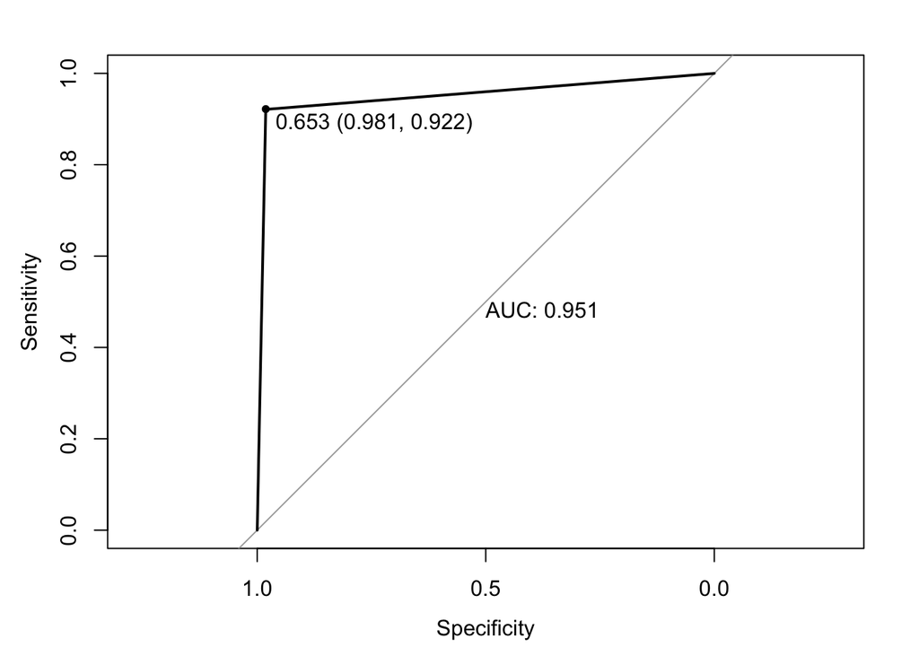

```r
plot.roc(res.roc, print.auc = TRUE, print.thres = "best")
```

# Advanced logistic regression

Try to modify the loss function in a Ridge Regression way or something else… to prepare the algorithm to work on not perfectly separated test data.

# Visualise the separation

Done in the other document on PCA. Could also work with LDA or SVM.